# Street Style Stories: What Pedestrian Clothing Reveals About Colour and Age

## Street Style Stories: What Pedestrian Clothing Reveals About Colour and Age

Have you ever wondered what the people walking past you on the street are wearing and whether there are patterns hiding in plain sight? Over a two-week period, I observed and logged the clothing of pedestrians in public spaces, recording three key details each time: the type of top they were wearing, its main colour, and an estimate of their age.

This visual story explores the data collected from 40 observations, revealing trends in colour preference, collection patterns over time, and the relationship between age and color choices.

## The Colour Landscape

The first thing I wanted to understand was simple: what colours do people actually wear? The data tells a clear story.

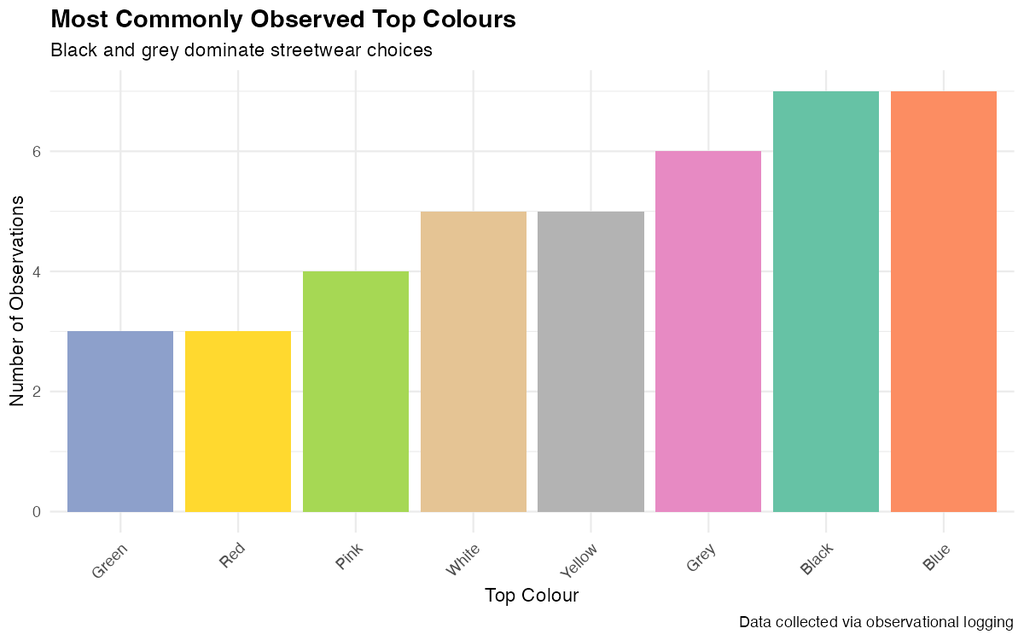

plot1.png

Black and blue emerged as the most commonly observed colours, each appearing in 7 observations. Grey followed closely with 6, while white and yellow tied at 5 each. Pink, green, and red were the least frequent — each appearing only 3 to 4 times，suggesting that while people do wear color, neutral and darker tones dominate everyday public settings.

## Tracking Observations Over Time

The next question was about when I collected data — and whether the estimated age of pedestrians changed over the course of my observation session.

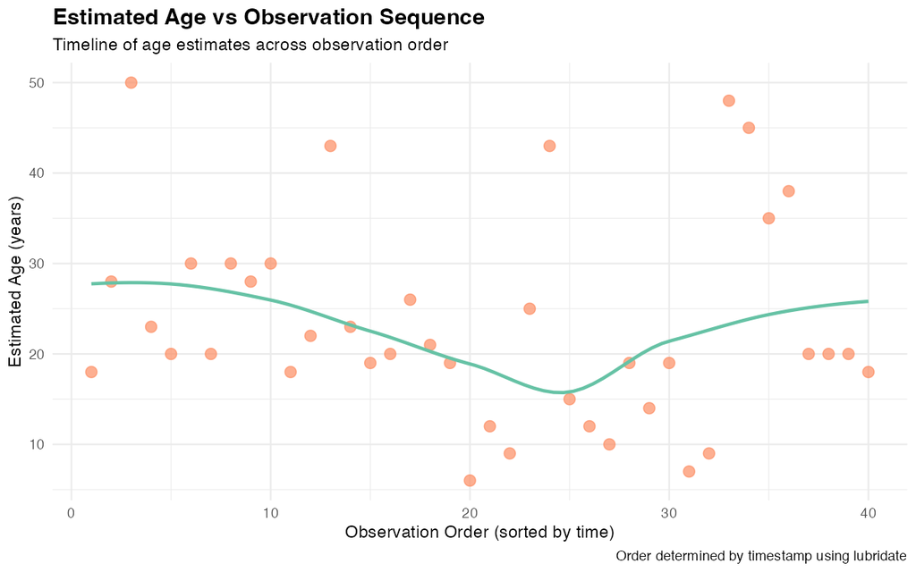

plot2.png

## Age and Colour Choices

Finally, I wanted to explore whether age was related to the tone of clothing people chose. I split colours into two broad groups — dark tones (black, grey, blue, green) and light tones (white, yellow, pink, red) — and compared estimated ages.

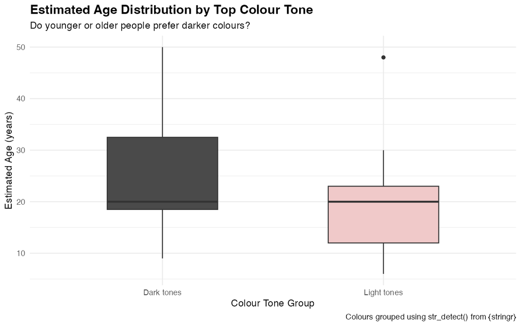

plot3.png

## What the Data Tells Us

Across 40 observations of everyday pedestrians, a few patterns emerged clearly:

Neutral colours rule the street. Black, grey, and blue were the most frequently observed top colours.

Age does not strongly predict colour choice in this small sample, suggesting other factors are at play.

Observation patterns remind us that data is shaped by the observer, not just the observed my own routine dictated when and where data was collected.

This project was a reminder that even simple, everyday observations if logged consistently can reveal interesting patterns. The next time you walk down the street, take a look around. What do you notice?